# ps05-rmarkdown-plot

Zack Tisdale

2023-02-17

## 1. Load and Check Data (5pts)

The data loading in:

```r
gapMinder <- read_delim("data/gapminder.csv.bz2")
```

The dimensions are as follows 13055, 25

A sample of the data is as follows

```r
head(gapMinder,5)
```

```
## # A tibble: 5 × 25
##   iso3  name  iso2  region sub-r…¹ inter…²  time total…³ ferti…⁴ lifeE…⁵ child…⁶
##   <chr> <chr> <chr> <chr>  <chr>   <chr>   <dbl>   <dbl>   <dbl>   <dbl>   <dbl>
## 1 ABW   Aruba AW    Ameri… Latin … Caribb…  1960   54211    4.82    65.7      NA
## 2 ABW   Aruba AW    Ameri… Latin … Caribb…  1961   55438    4.66    66.1      NA
## 3 ABW   Aruba AW    Ameri… Latin … Caribb…  1962   56225    4.47    66.4      NA
## 4 ABW   Aruba AW    Ameri… Latin … Caribb…  1963   56695    4.27    66.8      NA
## 5 ABW   Aruba AW    Ameri… Latin … Caribb…  1964   57032    4.06    67.1      NA
## # … with 14 more variables: youthFemaleLiteracy <dbl>, youthMaleLiteracy <dbl>,
## #   adultLiteracy <dbl>, GDP_PC <dbl>, accessElectricity <dbl>,
## #   agriculturalLand <dbl>, agricultureTractors <dbl>, cerealProduction <dbl>,
## #   fertilizerHa <dbl>, co2 <dbl>, greenhouseGases <dbl>, co2_PC <dbl>,
## #   pm2.5_35 <dbl>, battleDeaths <dbl>, and abbreviated variable names
## #   ¹`sub-region`, ²`intermediate-region`, ³totalPopulation, ⁴fertilityRate,
## #   ⁵lifeExpectancy, ⁶childMortality
```

It doesn’t look too good

## 2. descriptive Statistics (15pts)

1. (3pt) How many countries are there in the dataset? Analyze all three: iso3, iso2 and name.

Country count in iso3

```r
gapMinder %>%
  select(iso3) %>%
  na.omit() %>%
  summarize(n = n_distinct(iso3))
```

```
## # A tibble: 1 × 1
##       n
##   <int>
## 1   253
```

Country count in iso2

```r
gapMinder %>%
  select(iso2) %>%
  na.omit() %>%
  summarize(n = n_distinct(iso2))
```

```
## # A tibble: 1 × 1
##       n
##   <int>
## 1   248
```

Country count in name

```r
gapMinder %>%
  select(name) %>%
  na.omit() %>%
  summarize(n = n_distinct(name))
```

```
## # A tibble: 1 × 1
##       n
##   <int>
## 1   249
```

2. If you did this correctly, you saw that there are more names than iso-2 codes, and there are even more iso3 -codes. What is going on? Can you find it out?
1. (5pt) Find how many names are there for each iso-2 code. Are there any iso-2 codes that correspond to more than one name? What are these countries?

Names

```r
gapMinder%>%
   filter(is.na(name)) %>%
   distinct(iso2)
```

```
## # A tibble: 1 × 1
##   iso2
##   <chr>
## 1 <NA>
```

2. (5pt) Now repeat the same for name and iso3-code. Are there country names that have more than one iso3-code? What are these countries? Hint: two of these entitites are CHANISL and NLD CURACAO.

```r
gapMinder%>%
   filter(is.na(name)) %>%
   distinct(iso3)
```

```
## # A tibble: 4 × 1
##   iso3
##   <chr>
## 1 CHANISL
## 2 GBM
## 3 KOS
## 4 NLD_CURACAO
```

3. (2pt) What is the minimum and maximum year in these data? min

```r
gapMinder %>%
  select(time) %>%
  na.omit() %>%
  min()
```

```
## [1] 1960
```

max

```r
gapMinder %>%
  select(time) %>%
  na.omit %>%
  max()
```

```
## [1] 2019
```

## 3 Co2 emissions (30pt)

Next, let’s analyze CO2 emissions. 1. (2pt) How many missing co2 emissions are there for each year? Analyze both missing CO2 and co2_PC. Which years have most missing data?

Missing Co2 emissions stats for each year

```r
gapMinder %>%
  group_by(time) %>%
  select(co2,time) %>%
  summarize(n = sum(is.na(co2)))
```

```
## # A tibble: 61 × 2
##     time     n
##    <dbl> <int>
##  1  1960    60
##  2  1961    60
##  3  1962    58
##  4  1963    57
##  5  1964    51
##  6  1965    51
##  7  1966    51
##  8  1967    51
##  9  1968    51
## 10  1969    51
## # … with 51 more rows
```

Missing Co2_PC emissions stats for each year

```r
gapMinder %>%
  group_by(time) %>%
  select(co2_PC,time) %>%
  summarize(n = sum(is.na(co2_PC)))
```

```
## # A tibble: 61 × 2
##     time     n
##    <dbl> <int>
##  1  1960    60
##  2  1961    60
##  3  1962    58
##  4  1963    57
##  5  1964    51
##  6  1965    51
##  7  1966    51
##  8  1967    51
##  9  1968    51
## 10  1969    51
## # … with 51 more rows
```

Top 5 years with the most missing data for Co2

```r
gapMinder %>%
  group_by(time) %>%
  select(co2,time) %>%
  summarize(n = sum(is.na(co2))) %>%
  arrange(desc(n)) %>%
  head(5)
```

```
## # A tibble: 5 × 2
##    time     n
##   <dbl> <int>
## 1  2017   217
## 2  2018   217
## 3  2019   217
## 4  1960    60
## 5  1961    60
```

Top 5 years with the most missing data for co2_PC

```r
gapMinder %>%
  group_by(time) %>%
  select(co2_PC,time) %>%
  summarize(n = sum(is.na(co2_PC))) %>%
  arrange(desc(n)) %>%
  head(5)
```

```
## # A tibble: 5 × 2
##    time     n
##   <dbl> <int>
## 1  2017   217
## 2  2018   217
## 3  2019   217
## 4  1960    60
## 5  1961    60
```

2. (5pt) Make a plot of total CO2 emissions over time for the U.S, China, and India. Add a few more countries of your choice. Explain what do you see.

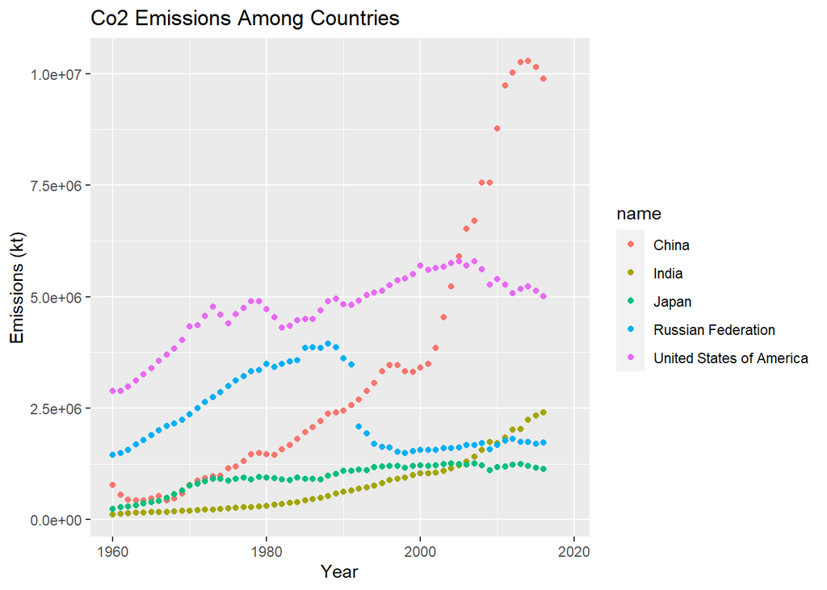

```r
miscCountries <- gapMinder %>%
  filter(name == 'United States of America'|name == 'China' | name == 'India'| name == 'Japan' | name == 'Russian Federation')
ggplot(miscCountries) +
  geom_point(aes(x = time, y = co2, col = name))+
  ggtitle("Co2 Emissions Among Countries")+
  xlab("Year") +
  ylab("Emissions (kt)")
```

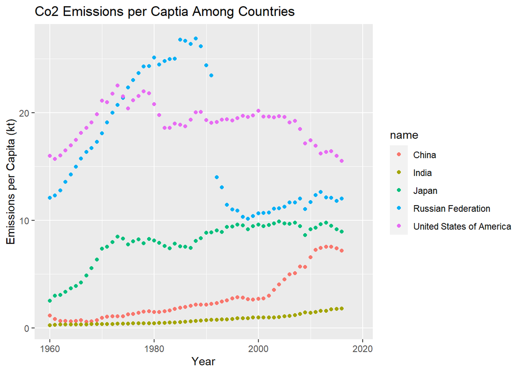

```r
ggplot(miscCountries) +
  geom_point(aes(x = time, y = co2_PC, col = name))+
  ggtitle("Co2 Emissions per Captia Among Countries")+
  xlab("Year") +
  ylab("Emissions per Capita (kt)")
```

4. (6pt) Compute average CO2 emissions per capita across the continents (assume region is the same as continent). Comment what do you see. Note: just compute averages over countries and ignore the fact that countries are of different size.

```r
continents <- gapMinder %>%
  select(time,region,co2_PC) %>%
  na.omit() %>%
  group_by(time,region) %>%
  summarize(n = mean(co2_PC))
```

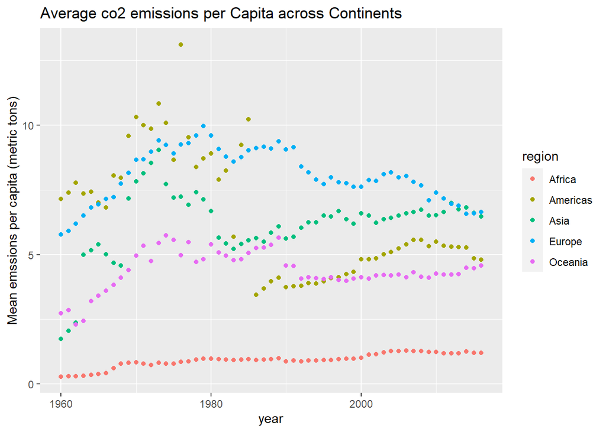

```r
ggplot(continents) +
  geom_point(aes(x = time, y = n, col = region)) +
  ggtitle("Average co2 emissions per Capita across Continents")+
  xlab("year")+
  ylab("Mean emssions per capita (metric tons)")
```

I see that the Americas, and Asia wre all over the charts near the beginning, and they started to level out more so after the 90s

Hint: Americas 2016 should be 4.80. 5. (7pt) Make a barplot where you show the previous results–average CO2 emissions per capita across continents in 1960 and 2016.

#### 3.4 attempt 2

```r
continents <- gapMinder %>%
  filter(time == 1960 | time == 2016) %>%
  select(region,co2_PC,time) %>%
  na.omit() %>%
  group_by(time,region) %>%
  summarize(n = mean(co2_PC))
continents
```

```
## # A tibble: 10 × 3
## # Groups:   time [2]
##     time region       n
##    <dbl> <chr>    <dbl>
##  1  1960 Africa   0.291
##  2  1960 Americas 7.15
##  3  1960 Asia     1.74
##  4  1960 Europe   5.77
##  5  1960 Oceania  2.73
##  6  2016 Africa   1.20
##  7  2016 Americas 4.80
##  8  2016 Asia     6.47
##  9  2016 Europe   6.64
## 10  2016 Oceania  4.57
```

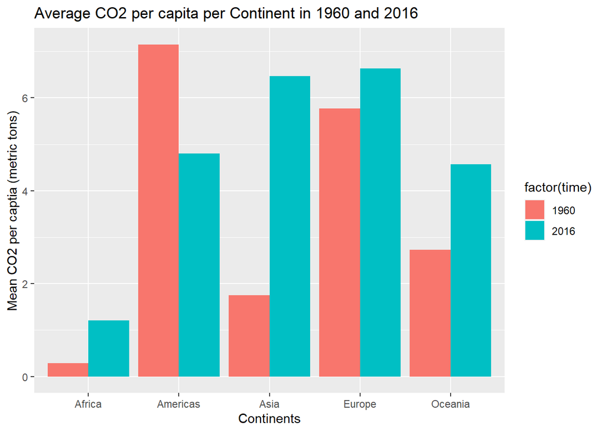

```r
ggplot(continents)+
  geom_col(aes(x = region, y = n, fill=factor(time)),position = "dodge") +
  ggtitle("Average CO2 per capita per Continent in 1960 and 2016")+
  xlab("Continents")+
  ylab("Mean CO2 per captia (metric tons)")
```

Let’s look at GDP per capita (GDP_PC ). 1. (8pt) Make a scatterplot of GDP per capita versus life expectancy by country, using data for 1960. Make the point size dependent on the country size, and color those according to the continent. Feel free to adjust the plot in other ways to make it better. Comment what do you see there.

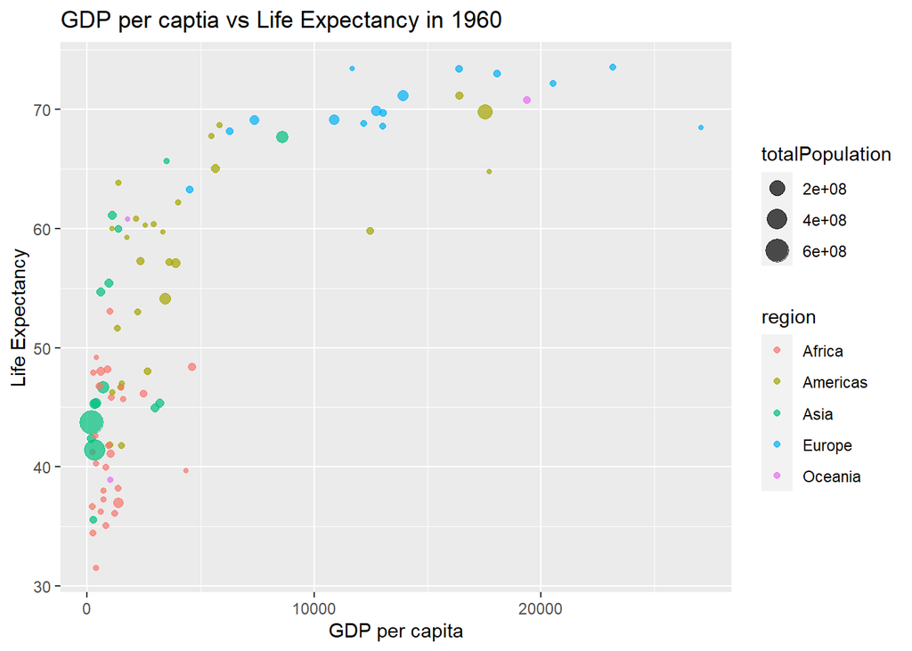

```r
countries1960 <- gapMinder %>%
  select(GDP_PC, time, lifeExpectancy, totalPopulation, region) %>%
  na.omit() %>%
  filter(time == 1960)

ggplot(countries1960) +
  geom_point(aes(x = GDP_PC, y = lifeExpectancy, size = totalPopulation, col = region),
             alpha = 0.7) +
  xlab("GDP per capita") +
  ylab("Life Expectancy")+
  ggtitle("GDP per captia vs Life Expectancy in 1960")
```

2. (4pt) Make a similar plot, but this time use 2019 data only.

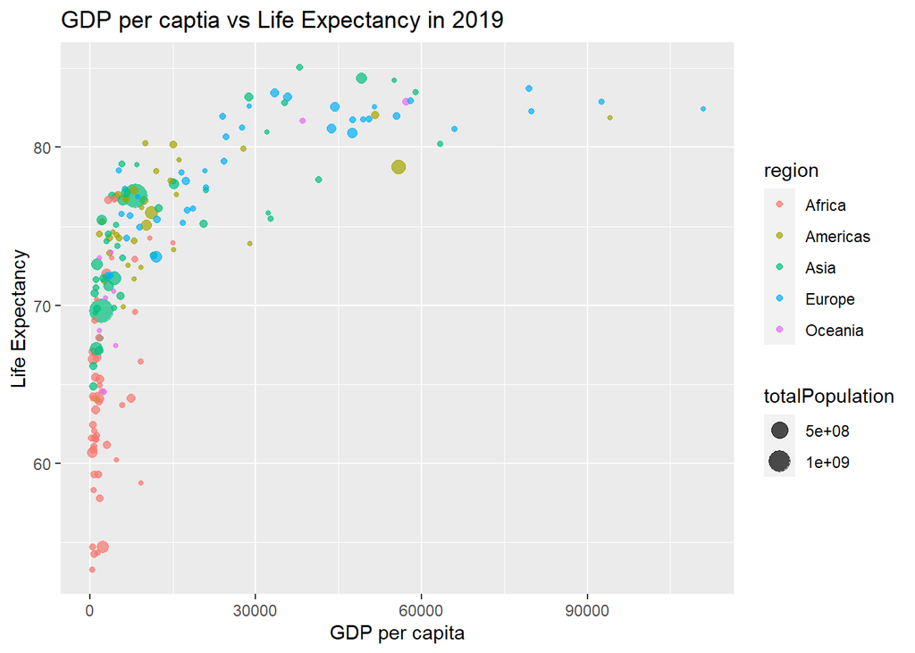

```r
countries2019 <- gapMinder %>%
  select(GDP_PC, time, lifeExpectancy, totalPopulation, region) %>%
  na.omit() %>%
  filter(time == 2019)

ggplot(countries2019) +
  geom_point(aes(x = GDP_PC, y = lifeExpectancy, size = totalPopulation, col = region),
             alpha = 0.7) +
  xlab("GDP per capita") +
  ylab("Life Expectancy")+
  ggtitle("GDP per captia vs Life Expectancy in 2019")
```

They fit 3. (6pt) Compare these two plots and comment what do you see. How has world developed through the last 60 years?

The life expectancy has congregated a lot higher up, the populations have grown a lot as well, and there seems to be a lot more countries with a higher gdp. Also centers of the graphs are farther right and higher.

4. (6pt) Compute the average life expectancy for each continent in 1960 and 2019. Do the results fit with what do you see on the figures? Note: here as average I mean just average over countries, ignore the fact that countries are of different size.

```r
lifeExpectancyTimes <- gapMinder %>%
  filter(time == 1960 | time == 2019) %>%
  group_by(region,time) %>%
  select(region,time,lifeExpectancy) %>%
  na.omit() %>%
  summarize(n = mean(lifeExpectancy))
```

[figure not shown]

```r
ggplot(lifeExpectancyTimes)+
  geom_col(aes(x = region, y = n, fill=factor(time)),position = "dodge") +
  ggtitle("Average Life Expectancy per Continent in 1960 and 2016")+
  xlab("Continents")+
  ylab("Mean Life Expectancy")
```

I think the results fit with the figures that were created

5. (8pt) Compute the average LE growth from 1960-2019 across the continents. Show the results in the order of growth. Explain what do you see. Hint: these data (data in long form) is not the simplest to compute growth. But you may want to check out the lag() function. And do not forget to group data by continent when using lag(), otherwise your results will be messed up! See https://faculty.washington. edu/otoomet/info201-book/dplyr.html#dplyr-helpers-compute.

```r
LEGrowth <- gapMinder %>%
  filter(time == 1960| time == 2019) %>%
  group_by(region, time) %>%
  select(region,time,lifeExpectancy) %>%
  na.omit %>%
  summarize(n = mean(lifeExpectancy)) %>%
  mutate(prev = lag(n),
         growth = n - prev) %>%
  na.omit() %>%
  arrange(desc(growth)) %>%
  select(region,growth)
LEGrowth
```

```
## # A tibble: 5 × 2
## # Groups:   region [5]
##   region   growth
##   <chr>     <dbl>
## 1 Asia       23.0
## 2 Africa     22.6
## 3 Americas   17.2
## 4 Oceania    17.1
## 5 Europe     11.1
```

I see that the order of the biggest growth, also that the continents that had the largest highest life expectancy increased the it seems.

6. (6pt) Show the histogram of GDP per capita for years of 1960 and 2019. Try to put both histograms on the same graph, see how well you can do it!

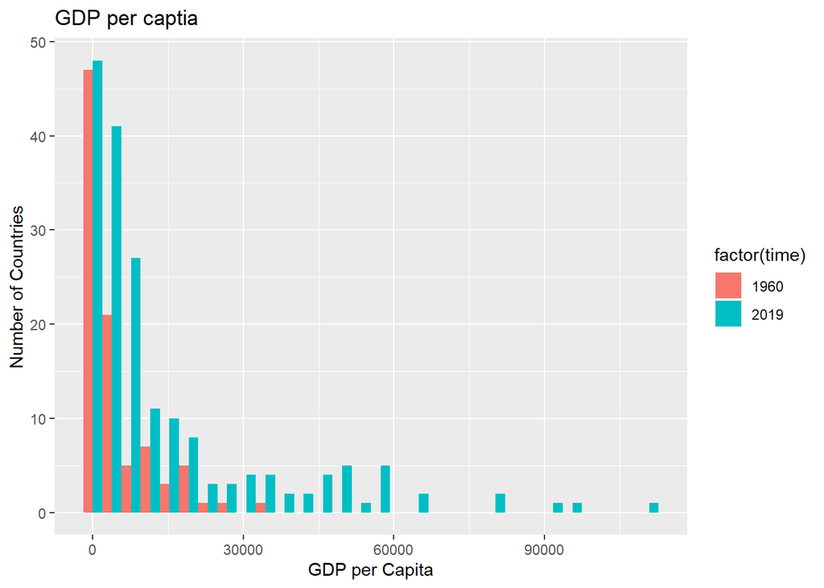

```r
gpdPerCaptia <- gapMinder %>%
  filter(time == 1960| time == 2019) %>%
  group_by(time) %>%
  select(GDP_PC,time) %>%
  na.omit()
ggplot(gpdPerCaptia) +
  geom_histogram(aes(x = GDP_PC, fill = factor(time)),position = "dodge") +
  ggtitle("GDP per captia")+
  xlab("GDP per Capita") +
  ylab("Number of Countries")
```

7. (6pt) What was the ranking of US in terms of life expectancy in 1960 and in 2019? (When counting from top.) Hint: check out the function rank()! Hint2: 17 for 1960.

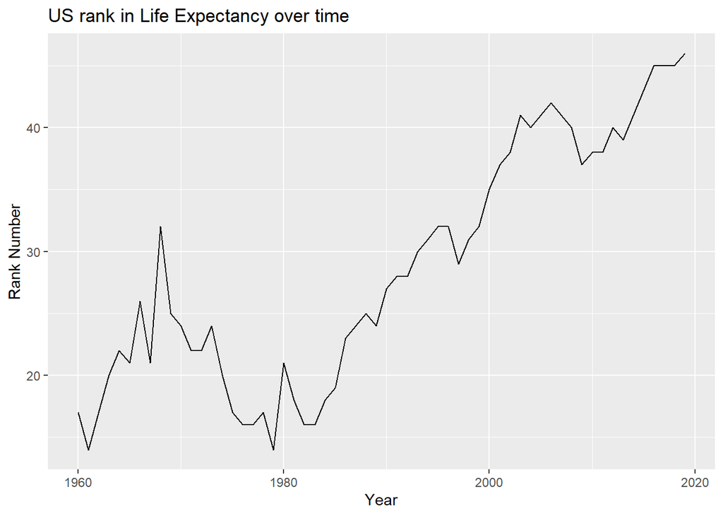

```r
usLifeExpectancyRank <- gapMinder %>%
  group_by(time) %>%
  select(name,time,lifeExpectancy) %>%
  na.omit %>%
  mutate(rank = rank(desc(lifeExpectancy))) %>%
  filter(name == 'United States of America') %>%
  select(rank,time)
ggplot(usLifeExpectancyRank)+
  geom_line(aes(x = time, y = rank)) +
  ggtitle("US rank in Life Expectancy over time") +
  xlab("Year") +
  ylab("Rank Number")
```

8. (6pt) If you did this correctly, then you noticed that US ranking has been falling quite a bit. But we also have more countries in 2019–what about the relative rank divided by the corresponding number of countries that have LE data in the corresponding year? Hint: 0.0904 for 1960.

```r
usLifeRelativeExpectancyRank <- gapMinder %>%
  group_by(time) %>%
  select(name,time,lifeExpectancy) %>%
  na.omit %>%
  mutate(rank = rank(desc(lifeExpectancy))/n_distinct(name)) %>%
  filter(name == 'United States of America') %>%
  select(rank,time)
usLifeRelativeExpectancyRank
```

```
## # A tibble: 60 × 2
## # Groups:   time [60]
##      rank  time
##     <dbl> <dbl>
##  1 0.0904  1960
##  2 0.0741  1961
##  3 0.0899  1962
##  4 0.106   1963
##  5 0.117   1964
##  6 0.111   1965
##  7 0.138   1966
##  8 0.111   1967
##  9 0.169   1968
## 10 0.132   1969
## # … with 50 more rows
```

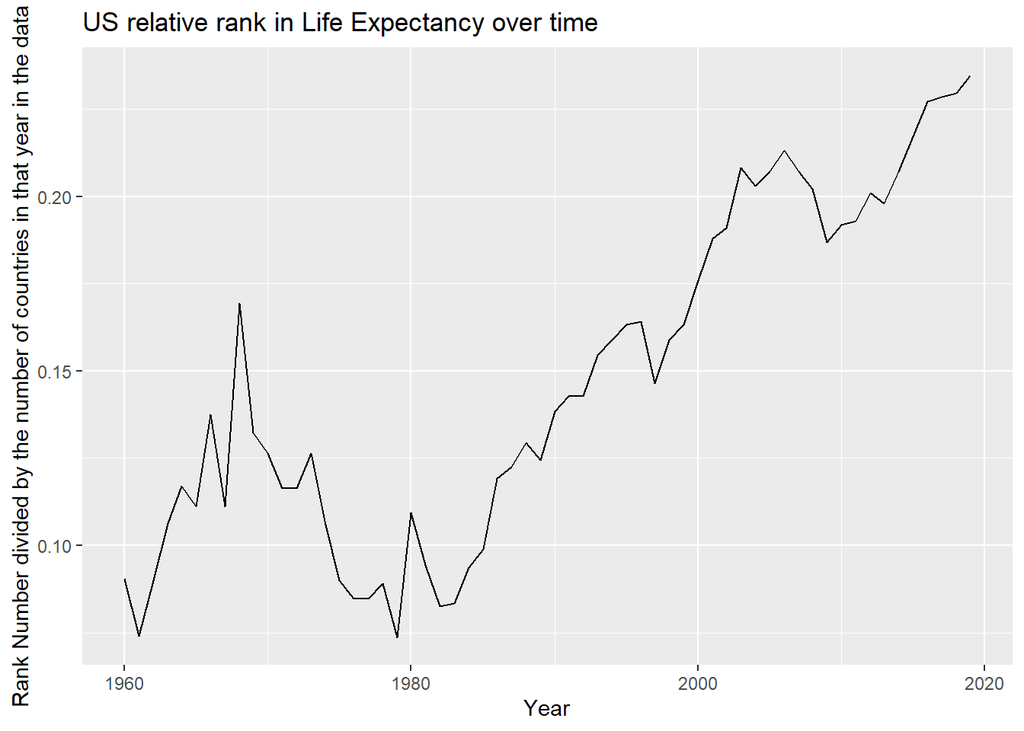

```r
ggplot(usLifeRelativeExpectancyRank)+
  geom_line(aes(x = time, y = rank)) +
  ggtitle("US relative rank in Life Expectancy over time") +
  xlab("Year") +
  ylab("Rank Number divided by the number of countries in that year in the data")
```

Finally tell us how many hours did you spend on this PS.